# SearchablePDF_to_Data

This notebook will walkthrough how to convert searchable PDFs into datasets.

## **STEP 1 : Install Tabula**

To do this visit : https://tabula.technology/ and download for windows.

Unzip the folder and place it somewhere easy to find.

Then within the unzipped folder double click "tabula.exe" You may need to download or update Java for this to work, it will promt you when you launch.

After launching a internet browser tab should open that looks like below:

[figure not shown]

## STEP 2 : Visualize your PDF to Data conversion

While you can run Tabula directley in Python it is very helpful to vizualize the data generating process before running script in Python.

To do this load a scearhable PDF into Tabula and then hit "Import"

After Import you will see something like below (obviously will look different using different data)

To get best results it is best to highlight only the portions of pages that are tables. You can also right click the selection and add it to all pages if you uploaded a multi page PDF with a similar format on each page.

[figure not shown]

Below is the table output from Tabula based on my selection above. As you can see Tabula is not perfect and will sometimes place words in columns they should not be.

As of now, I have not found a workaround for this other than either hand editing the results .csv or editing the individual .csv in stata afterword to get the columns to match up.

[figure not shown]

## Two Type of Data.

**NOTE :** There are two types of tables.

1. Tables whos cells are not seperated by lines/boxes
2. Tables whos cells are seperated by lines/boxes.

For data whos cells are not seperated by lines/boxes use the "stream" option.

For data whos cells are seperated by lines/boxes use the "lattice" option.

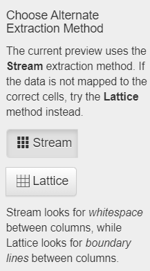

### You can stop here if you do not want to automate the process with Python and instead want to convert each PDF (or PDF page) to data by hand. Just repeat the steps above, exporting .csv by .csv and then combine and clean them at the end using Stata.

## STEP 3 : Automate using Python

After you have tried all possible selection option in Tabula and have seen the resulting .csv, find your prefered selections for each page and instead of exporting as .csv select export as script, as shown below:

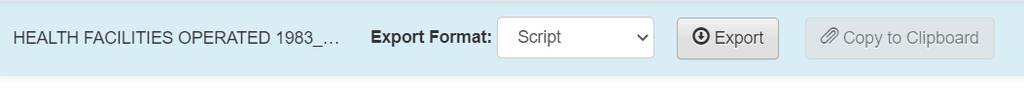

Then open the exported scrip in notepad or notepad++.

You will see the following :

[figure not shown]

These coordinates will be used in the next step to tell python where on each page to create a table.

We will need to download one more package in Python :

- pip install tabula

Once tabula package is install open up Spyder again and copy the code below into Spyder Editor.

Pay close attention to the comments in the below code if you have multiplte different pages of PDF with different selection boundaries.

NOTE: The Numbers highlighted in red above correspond with the area option below.

```python
import tabula
# Get list of PDF in folder
import os
from os import listdir
from os.path import isfile, join

#This command will turn all searchable pdfs within the folder into datasets.
#It is important you keep similar PDF in seperate folders.
#If you need to repeat the code below for several folders with different selection boundaries then do so.
#This will save all .csv into the "searchable_pdf folder"
#NOTE: stream option means no lines are in the tables, guess = false makes stream work, area was found in tabula.io
dir = r"C:/Users/kylem/Desktop/convertPDF/searchable_pdf"
os.chdir(dir)
tabula.convert_into_by_batch(dir, output_format="csv",
                             pages="all",
                             stream=True,
                             guess=False,
                             area=[216.386, 286.818, 1506.216, 2114.077]
                             )
```